# 課題3-2「画像処理・CVアプリケーションの自作」

【学生番号】17C1102  
【氏 名】中岡 翼

## 課題内容

興味のある画像処理・コンピュータビジョンの技術について調査を行い、 その技術に関連して自身で作成した画像処理・CVに関するアプリケーションを提出せよ。

- 以下を必ず説明すること
  - 何をするアプリケーションであるか
  - どのような技術を用いているか
  - そのアプリケーションのアピールポイント
- ただし、以下の点に留意すること
  - 技術ブログなどは参考にしてもいいがコピペのみは不可
    - 参考にした場合は必ず引用すること
  - 必ず動作検証が可能な状態で提供すること
  - 特に、Python以外の場合は
    - 動作環境についての説明と検証方法も示すこと
    - アプリケーション本体のソースコード及び、ビルドスクリプトも提供すること（バイナリのみは不可）
    - GitHubやGoogleDrive, DropBoxなどの外部サイトからダウンロードできる形式でも良いが必ずmanabaにアップロードした提出物（ファイル）から辿れるようにしておくこと

## レポート提出について

1. 締め切り：2020年1月17日（金）24:00
   - 締め切り後の提出は不可
2. 提出形式：
   - 形式：
     - 記述式：A4サイズのpdf（枚数は各課題につき最大で2枚）
     - プログラム：Jupyter notebook を HTML 化したものを提出すること（前回と同様、拡張子は「.html」）
     - ファイル名は「学生番号_名前_課題3-x-y.拡張子」とすること
   - 提出の際には全てのファイルの先頭に学生番号と氏名を記入すること（例：17Cxxxx_千葉工太郎_課題3-1-1.html）
   - 【注意】出力画像は上記HTMLに貼り込むこと
3. 提出先：[manaba](https://cit.manaba.jp/ct)

## 動作環境

- OS：macOS Catalina
- Python 3.8.1

## コードについて

出力画像，及び動画はHTML内で埋め込んでいるが、GitHubにも動作できるようコードを上げておく。

- [GitHub](https://github.com/NakaokaTsubasa/Robot_Vision)

## アプリケーションの説明

現在、YouTubeなどでは顔を隠して自身の動画を撮影する人たちが増えている。しかし、動画を撮ってから顔を隠すために編集ソフトなどを用いて処理を施すと、１フレームごとに顔を隠すための画像などを移動させなければならないため、時間がかかってしまうという欠点がある。そこで、OpenCVに入っている顔検出を用いて、顔部分に黒塗りをする処置を行った。また、OpenCVに入っている顔検出のみでは精度が低く、うまく検出されていないフレームが多いため、テンプレートマッチングを組み合わせて顔検出がされていないフレームを補間する処理を行った。

## 必要なライブラリのインポート

```python
import numpy as np
import cv2
import matplotlib.pyplot as plt
import IPython.display
```

## OpenCVを用いた顔検出

以下のコードはOpenCVに入っている顔検出を用いて顔画像の取得を行った。出力された画像は左からそれぞれ、元画像、顔を検出した枠、出したところのみを切り取った画像となっている。分類器は"haarcascade_frontalface_default.xml"を用いた。

[figure not shown]

```python
face_cascade = cv2.CascadeClassifier('haarcascade_frontalface_default.xml')

img = cv2.imread('data/lenna.png')

# OpenCVのカスケードファイル "haarcascade_frontalface_default.xml" を用いて顔画像の取得

# 顔の認識
gray = cv2.cvtColor(img, cv2.COLOR_BGR2GRAY)
faces = face_cascade.detectMultiScale(gray, 1.3, 5)

# 全体画像の表示
img = cv2.cvtColor(img, cv2.COLOR_BGR2RGB)
plt.figure(figsize=(20, 12))
plt.subplot(1, 3, 1)
plt.imshow(img)

# 顔認識の描画
x, y, w, h = faces[0]
face_rec = img.copy()
cv2.rectangle(face_rec, (x, y), (x + w, y + h), (255, 0, 0), thickness=3)
plt.subplot(1, 3, 2)
plt.imshow(face_rec)

# 認識した顔の切り取り
face_img = img[y: y + h, x: x + w]
plt.subplot(1, 3, 3)
plt.imshow(face_img)
plt.show()
```

## テンプレートマッチングを用いた顔検出

上記の得た顔画像を探索画像として、テンプレートマッチングを行った。テンプレートマッチングとは、全体画像から一部切り取った画像を左上から順に見比べ、一致している場所を探す探索方法である。出力画像は左から、元画像、上記より切り取った顔画像（探索画像）、検出された場所となっている。結果のように、顔画像の座標を取得することができた。

[figure not shown]

```python
# 上記で得た顔の切り取り画像を用いてテンプレートマッチングを行う

# 全体画像の表示
plt.figure(figsize=(20, 12))
plt.subplot(1, 3, 1)
plt.imshow(img)

# 上記で得た顔の切り取り
plt.subplot(1, 3, 2)
plt.imshow(face_img)

# テンプレートマッチング
tem_rec = img.copy()
res = cv2.matchTemplate(face_img, tem_rec, cv2.TM_CCOEFF_NORMED)
minVal, maxVal, minLoc, maxLoc = cv2.minMaxLoc(res)
x_, y_, w_, h_ = maxLoc[0], maxLoc[1], len(face_img), len(face_img)
cv2.rectangle(tem_rec, (x_, y_), (x_ + w_, y_ + h_), (255, 0, 0), thickness=3)
plt.subplot(1, 3, 3)
plt.imshow(tem_rec)
plt.show()
```

## 元動画

```python
fourcc = cv2.VideoWriter_fourcc('m','p','4','v')
cap = cv2.VideoCapture('data/test.mov')
out = cv2.VideoWriter("test.mp4", fourcc, 30.0, (1280,720))
```

```python
# 音無しの元データ作成
while (cap.isOpened()):
    ret, img = cap.read()
    if (ret == False):
        break
    out.write(img)
out.release()

# 動画の再生(YouTube)
IPython.display.YouTubeVideo('1RV3GGwAHrM')
```

[video not shown]

## OpenCVのみを用いた顔検出

以下はOpenCVのみを用いて顔検出を行った結果である。動画を見ると、上下左右の方向を向いているフレームはうまく検出することができず、顔が見えてしまっている。

```python
cap = cv2.VideoCapture('data/test.mov')
out = cv2.VideoWriter("opencv_output.mp4", fourcc, 30.0, (1280,720))

# OpenCV内入っている "haarcascade_frontalface_default.xml" のみを用いた顔認識による 顔の塗り潰し
while (cap.isOpened()):
    ret, img = cap.read()
    if (ret == False):
        break
    gray = cv2.cvtColor(img, cv2.COLOR_BGR2GRAY)
    faces = face_cascade.detectMultiScale(gray, 1.3, 5)
    for x, y, w, h in faces:
        img[y: y + h, x: x + w] = [0, 0, 0]
    out.write(img)
out.release()

# 動画の再生（YouTube）
IPython.display.YouTubeVideo('gJG9AOmhHqU')
```

[video not shown]

## OpenCVとテンプレートマッチングを用いた顔検出

次に、OpenCVとテンプレートマッチングを組み合わせて顔検出の精度を上げたコードと動画である。はじめにOpenCVの顔検出を用いて顔の黒塗りを行い、もし顔検出することができなかった場合、前のフレームの顔画像を探索画像とし、現在のフレームの全体画像をマッチングさせた。結果、上記でうまく検出できずに顔が見えてしまった場所が、今回のコードでは綺麗に顔を隠すことができた。

```python
cap = cv2.VideoCapture('data/test.mov')
out = cv2.VideoWriter("output.mp4", fourcc, 30.0, (1280,720))

# "haarcascade_frontalface_default.xml" を用いた顔認識 と テンプレートマッチングを用いた顔のマッチングによる 顔の塗り潰し
while (cap.isOpened()):
    ret, img = cap.read()
    if (ret == False):
        break
    gray = cv2.cvtColor(img, cv2.COLOR_BGR2GRAY)
    faces = face_cascade.detectMultiScale(gray, 1.3, 5)
    if ((type(faces) is tuple) == False):
        for x, y, w, h in faces:
            img_ = img[y: y + h, x: x + w]
            img_ = cv2.cvtColor(img_, cv2.COLOR_BGR2RGB)
            img[y: y + h, x: x + w] = [0, 0, 0]
    elif ((type(faces) is tuple) == True):
        res = cv2.matchTemplate(img_, img, cv2.TM_CCOEFF_NORMED)
        minVal, maxVal, minLoc, maxLoc = cv2.minMaxLoc(res)
        x_, y_, w_, h_ = maxLoc[0], maxLoc[1], len(img_), len(img_)
        img_ = img[y_: y_ + h_, x_: x_ + w_]
        img_ = cv2.cvtColor(img_, cv2.COLOR_BGR2RGB)
        img[y_: y_ + h_, x_: x_ + w_] = [0, 0, 0]
    out.write(img)
out.release()

# 動画の再生（YouTube）
IPython.display.YouTubeVideo('rMBpBgWObjk')
```

[video not shown]

以下の画像はテンプレートマッチングを行っている処理で、左からそれぞれ、1フレーム前の顔画像（探索画像）、現在のフレーム画像で顔を検出された場所、検出された顔画像となっている。

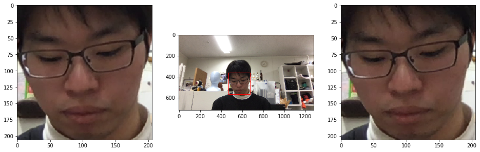

```python
cap = cv2.VideoCapture('data/test.mov')

# 数が多いので任意の1フレームを表示(この場合 156 フレーム目)
n = 156

# OpenCVで認識できなかった場合、現在の1つ前のフレームの顔画像を探索画像とし、テンプレートマッチングを行う
frame = 0
while (cap.isOpened()):
    ret, img = cap.read()
    if (ret == False):
        break
    gray = cv2.cvtColor(img, cv2.COLOR_BGR2GRAY)
    faces = face_cascade.detectMultiScale(gray, 1.3, 5)
    img = cv2.cvtColor(img, cv2.COLOR_BGR2RGB)
    total_img = img.copy()
    if ((type(faces) is tuple) == False):
        for x, y, w, h in faces:
            img_ = img[y: y + h, x: x + w]
    elif ((type(faces) is tuple) == True):
        if (frame == n):
            plt.figure(figsize=(16, 9))
            plt.subplot(1, 3, 1)
            plt.imshow(img_) # 探索画像(1つ前のフレーム)
        res = cv2.matchTemplate(img_, img, cv2.TM_CCOEFF_NORMED)
        minVal, maxVal, minLoc, maxLoc = cv2.minMaxLoc(res)
        x_, y_, w_, h_ = maxLoc[0], maxLoc[1], len(img_), len(img_)
        img_ = img[y_: y_ + h_, x_: x_ + w_]
        cv2.rectangle(total_img, (x_, y_), (x_ + w_, y_ + h_), (255, 0, 0), thickness=3)
        if (frame == n):
            plt.subplot(1, 3, 2)
            plt.imshow(total_img) # 探索画像からテンプレートマッチングした結果
            plt.subplot(1, 3, 3)
            plt.imshow(img_) # 顔の切り取り(現在のフレーム)
            plt.show()
    frame += 1
```

## アピールポイント

アピールポイントとしては、OpenCVの初めから入っている分類器のみではなく、テンプレートマッチングを用いて顔検出の精度をさらに上げたところである。また、本来検出することが難しい上下方向に向いている画像であっても、しっかりと黒塗り処理をすることができた。

## 参考文献

- OpenCV-Pythonチュートリアル，（最終閲覧日：2020年1月17日）http://labs.eecs.tottori-u.ac.jp/sd/Member/oyamada/OpenCV/html/py_tutorials/py_imgproc/py_template_matching/py_template_matching.html
- Python, OpenCVで顔検出と瞳検出（顔認識、瞳認識），（最終閲覧日：2020年1月17日）https://note.nkmk.me/python-opencv-face-detection-haar-cascade/